# 1. Introduction

#### 4.2.1.3 Linear Model Results

Both models have a high R squared and adjusted R squared, the one for Temp of about 0.87 and the one for TempS of about 0.93. However, in both models the condition number is very large, indicating there might be some multicollinearity or other problems with the models. This is most likely because they are both time series data.

To further analyze the residuals, the predicted values and residuals are calculated and added to the data frame.

```python
# Add predicted values of linear models to dataframe
Combined_df['Temp_GGE_LM_pred'] = GGE_temp_lm.predict(Combined_df.GGE)
Combined_df['TempS_GGE_LM_pred'] = GGE_tempS_lm.predict(Combined_df.GGE)
```

```python
# Add residuals of linear models to dataframe
Combined_df['Temp_GGE_LM_resids'] = np.subtract(Combined_df.Temp_GGE_LM_pred, Combined_df.Temp)
Combined_df['TempS_GGE_LM_resids'] = np.subtract(Combined_df.TempS_GGE_LM_pred, Combined_df.TempS)
Combined_df.head(3)
```

|  | Year | Temp | TempS | Pop | GGE | Temp_LM_pred | TempS_LM_pred | Temp_LM_resids | TempS_LM_resids | Temp_GGE_LM_pred | TempS_GGE_LM_pred | Temp_GGE_LM_resids | TempS_GGE_LM_resids |
| --- | --- | --- | --- | --- | --- | --- | --- | --- | --- | --- | --- | --- | --- |
| 0 | 1950 | -0.17 | -0.07 | 2499322000 | 9.594495e+09 | -0.180266 | -0.177250 | -0.010266 | -0.107250 | -0.215119 | -0.212155 | -0.045119 | -0.142155 |
| 1 | 1951 | -0.07 | -0.07 | 2543130400 | 1.017205e+10 | -0.171889 | -0.168937 | -0.101889 | -0.098937 | -0.199254 | -0.196402 | -0.129254 | -0.126402 |
| 2 | 1952 | 0.01 | -0.07 | 2590271000 | 1.034623e+10 | -0.162874 | -0.159992 | -0.172874 | -0.089992 | -0.194469 | -0.191652 | -0.204469 | -0.121652 |

The predicted values together with the actual values of Temp and TempS are plotted.

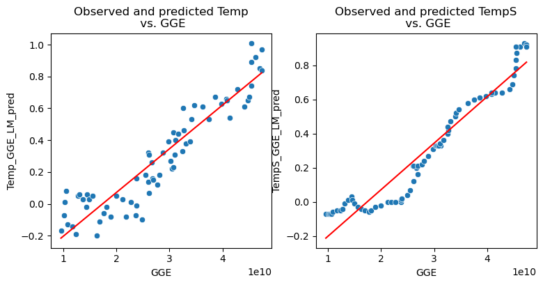

```python
plot_y1_and_y2_and_yhat1_and_yhat2_versus_x1_and_x2(Combined_df, 'GGE', 'GGE', 'Temp', 'TempS', \
                                  'Temp_GGE_LM_pred', 'TempS_GGE_LM_pred')
```

```python
print('Temp: The mean of the residuals = {0:4.3f}  RMSE = {1:4.3f}'.format(np.mean(Combined_df.Temp_GGE_LM_resids), np.std(Combined_df.Temp_GGE_LM_resids)))
print('TempS: The mean of the residuals = {0:4.3f}  RMSE = {1:4.3f}'.format(np.mean(Combined_df.TempS_GGE_LM_resids), np.std(Combined_df.TempS_GGE_LM_resids)))
```

```
Temp: The mean of the residuals = 0.000  RMSE = 0.121
TempS: The mean of the residuals = 0.000  RMSE = 0.085
```

**Figure 4.2.1.3.1** The fits look generally good. The RMSE with the smoothed temperatures has a lower RMSE, but the plot indicates that the model might not be ideal.

Next, the distributions of the residuals are analyzed.

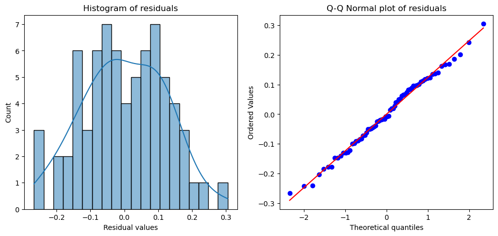

```python
plot_resid_dist(Combined_df.Temp_GGE_LM_resids)
```

**Figure 4.2.1.3.2** The residuals of the linear model with the raw temperature data look approximately normally distributed.

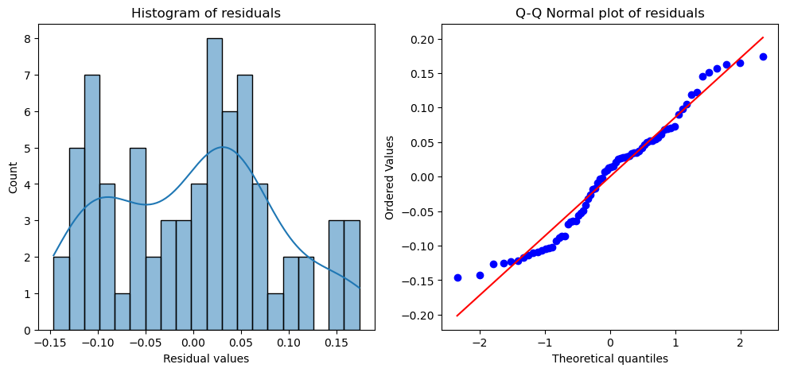

```python
plot_resid_dist(Combined_df.TempS_GGE_LM_resids)
```

**Figure 4.2.1.3.3** The residuals of the linear model with the smoothed temperature data have a bimodal distribution.

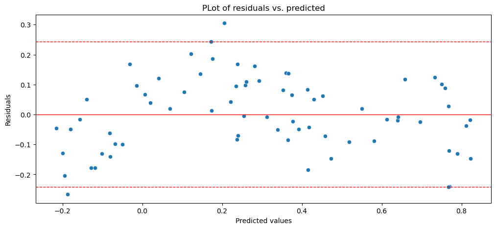

```python
residual_plot(Combined_df, 'Temp_GGE_LM_pred', 'Temp_GGE_LM_resids')
```

**Figure 4.2.1.3.4** The residuals of the linear model with the raw temperature data are heteroskedastic.

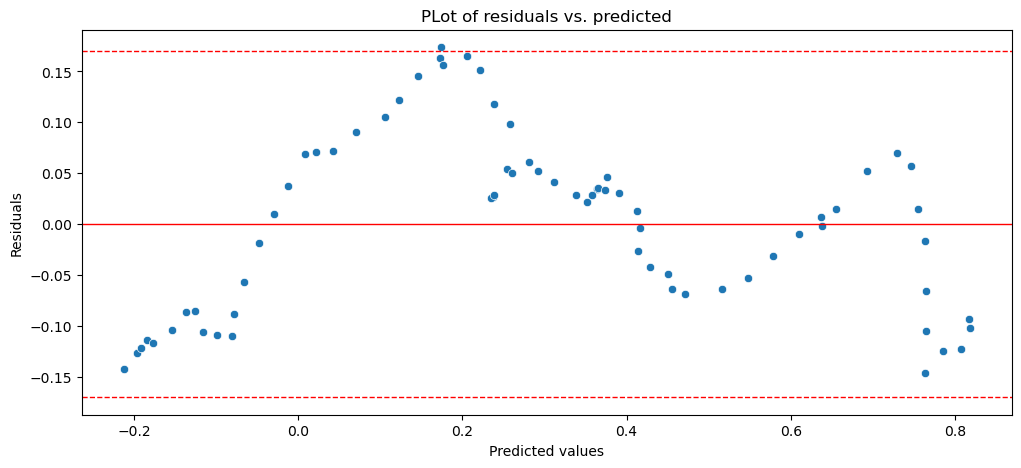

```python
residual_plot(Combined_df, 'TempS_GGE_LM_pred', 'TempS_GGE_LM_resids')
```

**Figure 4.2.1.3.5** The residuals of the linear model with the smoothed temperature data are also heteroskedastic.

Logarithmic linear models were attempted with either just a log transformation or a transformation with a lambda identified with the Box Cox method. Both did not improve the linear models (data not shown).

## 4.3 Greenhouse Gas Emissions versus Population

### 4.3.1 Linear Model

#### 4.3.1.1 Rationale for Linear Model Choice

Figure 3.2.3 shows a very strong positive correlations between greenhouse gas emissions and population. Next, we will explore if we can model this relationship with a linear model.

#### 4.3.1.2 Linear Model Building¶

The code below builds a linear model with greenhouse gas emissions (GGE) as dependent variable and population as independent variable.

```python
# Build a linear model with GGE versus Pop
GGE_Pop_lm = smf.ols(formula = 'GGE ~ Pop', data=Combined_df).fit()
GGE_Pop_lm.summary()
```

OLS Regression Results

| Dep. Variable: | GGE | R-squared: | 0.984 |
| --- | --- | --- | --- |
| Model: | OLS | Adj. R-squared: | 0.983 |
| Method: | Least Squares | F-statistic: | 4205. |
| Date: | Thu, 21 Dec 2023 | Prob (F-statistic): | 2.99e-64 |
| Time: | 16:19:44 | Log-Likelihood: | -1620.4 |
| No. Observations: | 72 | AIC: | 3245. |
| Df Residuals: | 70 | BIC: | 3249. |
| Df Model: | 1 |  |  |
| Covariance Type: | nonrobust |  |  |

|  | coef | std err | t | P>\|t\| | [0.025 | 0.975] |
| --- | --- | --- | --- | --- | --- | --- |
| Intercept | -5.627e+09 | 5.51e+08 | -10.209 | 0.000 | -6.73e+09 | -4.53e+09 |
| Pop | 6.7802 | 0.105 | 64.848 | 0.000 | 6.572 | 6.989 |

| Omnibus: | 4.222 | Durbin-Watson: | 0.161 |
| --- | --- | --- | --- |
| Prob(Omnibus): | 0.121 | Jarque-Bera (JB): | 2.273 |
| Skew: | 0.165 | Prob(JB): | 0.321 |
| Kurtosis: | 2.195 | Cond. No. | 1.69e+10 |

Notes:  
[1] Standard Errors assume that the covariance matrix of the errors is correctly specified.  
[2] The condition number is large, 1.69e+10. This might indicate that there are  
strong multicollinearity or other numerical problems.

This correlation is very strong with an R squared of 0.98.

#### 4.3.1.3 Linear Model Results

Next, we will make predictions using the linear model.

```python
Combined_df['GGE_Pop_LM_pred'] = GGE_Pop_lm.predict(Combined_df.Pop)
Combined_df['GGE_Pop_LM_resids'] = np.subtract(Combined_df.GGE_Pop_LM_pred, Combined_df.GGE)
```

Next, the actual and predicted GGE are plotted against population. First, a function to create a single plot is created and then applied to plot the actual and predicted GGE data.

```python
def plot_y_and_yhat_versus_x(df, x, y, yhat):
    # Plot independent variable versus temperature
    fig, ax = plt.subplots(nrows=1, ncols=1, figsize=(6, 5))
    sns.scatterplot(data=df, x=x, y=y)
    sns.lineplot(data=df, x=x, y=yhat, color="red", linewidth="2")
    ax.set_xlabel(x)
    ax.set_ylabel(y)
    ax.set_title(y + ' and ' + yhat + ' vs. ' + x)
    plt.show()
```

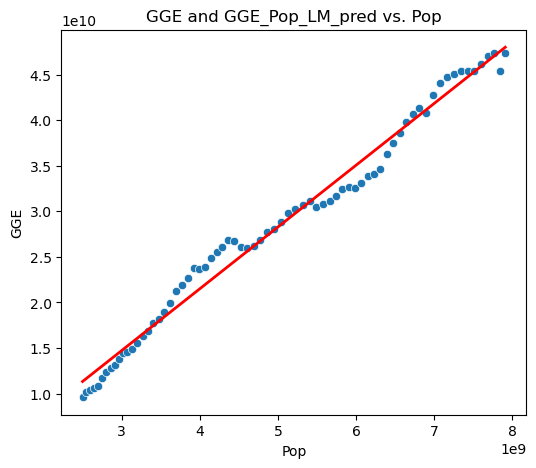

```python
plot_y_and_yhat_versus_x(Combined_df, 'Pop', 'GGE', 'GGE_Pop_LM_pred')
```

```python
print('GGE: The mean of the residuals = {0:4.3f}  RMSE = {1:4.3f}'.format(np.mean(Combined_df.GGE_Pop_LM_resids), np.std(Combined_df.GGE_Pop_LM_resids)))
```

```
GGE: The mean of the residuals = 0.000  RMSE = 1438491966.874
```

**Figure 4.3.1.3.1** The linear model seems to be a very good fit. Next, the residuals will be analyzed.

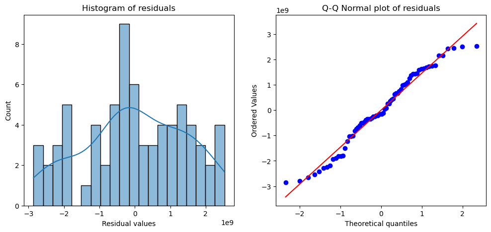

```python
plot_resid_dist(Combined_df.GGE_Pop_LM_resids)
```

**Figure 4.3.1.3.2** The residuals are not as well distributed as anticipated, but they are still close to normally distributed.

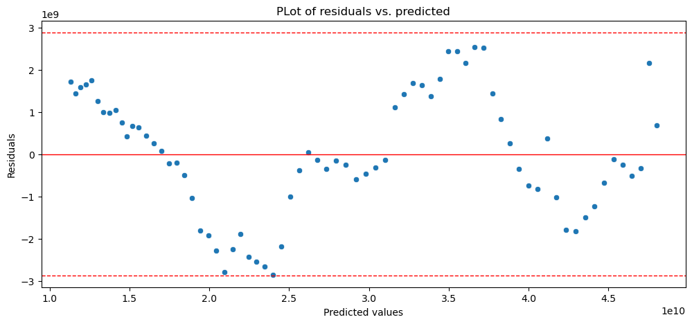

```python
residual_plot(Combined_df, 'GGE_Pop_LM_pred', 'GGE_Pop_LM_resids')
```

**Figure 4.3.1.2.3** There is a pattern, but it is not different on one side than on the other side. Also, none of the residuals are outside the confidence interval.

In summary, there is a clear positive correlation between human population and greenhouse gas emissions.

## 4.4 GDP versus Population

### 4.4.1 Linear Model with Transformed Dependent Variable

#### 4.4.1.1 Rationale for Linear Model with Transformed Dependent Variable Choice

Figure 3.2.4 shows a seemingly exponential correlations between GDP and population. Next, we will explore if we can model this relationship with a linear model with transformed dependent variable.

#### 4.4.1.2 Linear Model with Transformed Dependent Variable Building¶

Initially, a regular log model was built, but it overshot, i.e., the exponential relationship turned into a hyperbolic relationship. Therefore, the BoxCox method was used to find an ideal lambda. The code below builds a linear model with transformed GDP as dependent variable and population as independent variable. The Combined_df3 data frame will be used here. The transformed dependent variable GDP will be added to the data frame.

```python
# Determine ideal lambda with Box Cox method
fitted_data, fitted_lambda = ss.boxcox(Combined_df3.GDP)
print(fitted_lambda)
```

```
0.22450164762143898
```

```python
# Creating columns with centered population and Box Cox transformed GDP
Combined_df3['BoxCoxGDP'] = fitted_data
Combined_df3.head(3)
```

|  | Country name | Year | Pop | GDP | GGE | Temp | TempS | BoxCoxGDP |
| --- | --- | --- | --- | --- | --- | --- | --- | --- |
| 0 | World | 1960 | 3019233500 | 1.384860e+12 | 1.443040e+10 | -0.02 | 0.03 | 2364.442210 |
| 1 | World | 1961 | 3068370700 | 1.449220e+12 | 1.451612e+10 | 0.06 | 0.01 | 2388.724555 |
| 2 | World | 1962 | 3126686700 | 1.550820e+12 | 1.493749e+10 | 0.03 | -0.01 | 2425.407557 |

```python
# Building linear model with Box Cox transformed GDP
BoxCoxGDP_pop_lm = smf.ols(formula = 'BoxCoxGDP ~ Pop', data=Combined_df3).fit()
BoxCoxGDP_pop_lm.summary()
```

OLS Regression Results

| Dep. Variable: | BoxCoxGDP | R-squared: | 0.989 |
| --- | --- | --- | --- |
| Model: | OLS | Adj. R-squared: | 0.988 |
| Method: | Least Squares | F-statistic: | 5162. |
| Date: | Thu, 21 Dec 2023 | Prob (F-statistic): | 6.67e-60 |
| Time: | 16:19:44 | Log-Likelihood: | -387.59 |
| No. Observations: | 62 | AIC: | 779.2 |
| Df Residuals: | 60 | BIC: | 783.4 |
| Df Model: | 1 |  |  |
| Covariance Type: | nonrobust |  |  |

|  | coef | std err | t | P>\|t\| | [0.025 | 0.975] |
| --- | --- | --- | --- | --- | --- | --- |
| Intercept | 43.2525 | 61.459 | 0.704 | 0.484 | -79.684 | 166.189 |
| Pop | 7.922e-07 | 1.1e-08 | 71.845 | 0.000 | 7.7e-07 | 8.14e-07 |

| Omnibus: | 13.561 | Durbin-Watson: | 0.171 |
| --- | --- | --- | --- |
| Prob(Omnibus): | 0.001 | Jarque-Bera (JB): | 3.487 |
| Skew: | -0.069 | Prob(JB): | 0.175 |
| Kurtosis: | 1.846 | Cond. No. | 2.11e+10 |

Notes:  
[1] Standard Errors assume that the covariance matrix of the errors is correctly specified.  
[2] The condition number is large, 2.11e+10. This might indicate that there are  
strong multicollinearity or other numerical problems.

This linear model yields a very high R squared of 0.98.

#### 4.4.1.3 Linear Model with Transformed Dependent Variable Results

Next, we will investigate if predictions made with this model are close to the actual data.

```python
Combined_df3['BoxCoxGDP_Pop_LM_pred'] = BoxCoxGDP_pop_lm.predict(Combined_df3.Pop)
Combined_df3['BoxCoxGDP_Pop_LM_resids'] = np.subtract(Combined_df3.BoxCoxGDP_Pop_LM_pred, Combined_df3.BoxCoxGDP)
```

Next, the actual and predicted BoxCoxGDP are plotted against population.

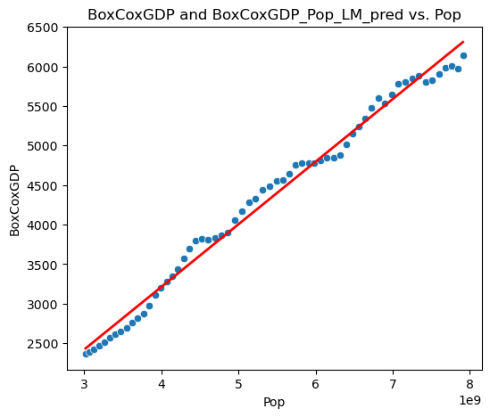

```python
plot_y_and_yhat_versus_x(Combined_df3, 'Pop', 'BoxCoxGDP', 'BoxCoxGDP_Pop_LM_pred')
```

```python
print('GDP: The mean of the residuals = {0:4.3f}  RMSE = {1:4.3f}'.format(np.mean(Combined_df3.BoxCoxGDP_Pop_LM_resids), np.std(Combined_df3.BoxCoxGDP_Pop_LM_resids)))
```

```
GDP: The mean of the residuals = 0.000  RMSE = 125.536
```

**Figure 4.4.1.3** This seems to be a very good fit with lambda = 0.225. Next, the residuals will be evaluated in more detail.

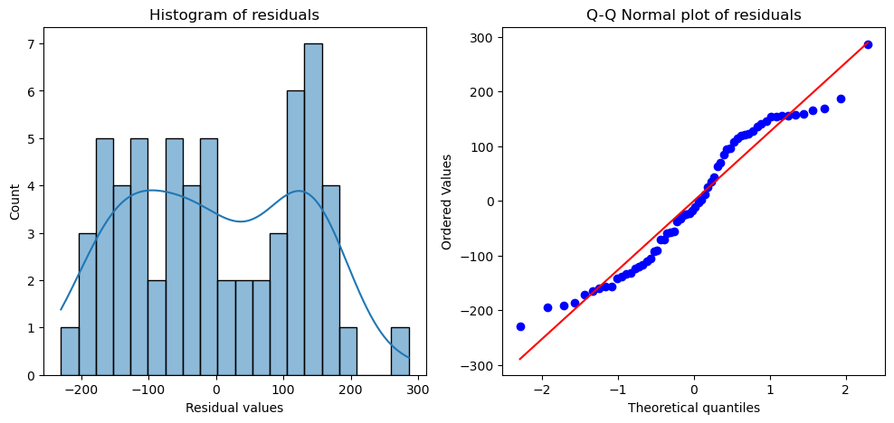

```python
plot_resid_dist(Combined_df3.BoxCoxGDP_Pop_LM_resids)
```

**Figure 4.4.1.4** The residuals have a bimodal distribution.

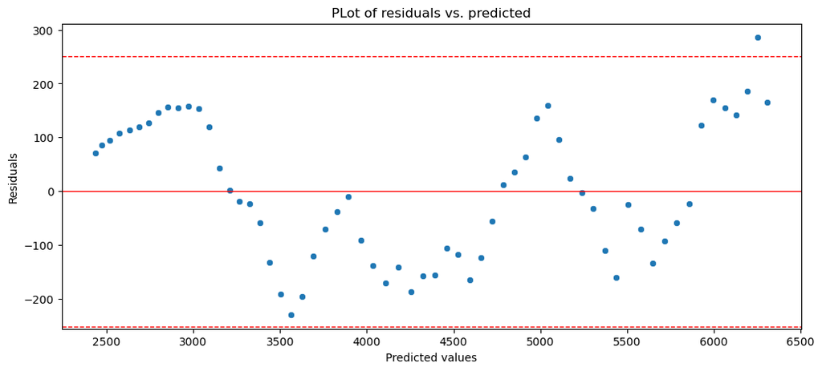

```python
residual_plot(Combined_df3, 'BoxCoxGDP_Pop_LM_pred', 'BoxCoxGDP_Pop_LM_resids')
```

**Figure 4.4.1.5** There are some "waves", which are probably the result of the time series, but overall the residuals seem to be homoskedastic. This seems to be a good model.

## 4.5 Temperature versus Other Variables and Interaction Terms

### 4.5.1 Multivariate Linear Model with Interaction Terms

#### 4.5.1.1 Rationale for Multivariate Linear Model with Interaction Terms

We have seen above that the global temperature depends on population and greenhouse gas emissions, while the correlation with GDP was not that clear. Plus, GDP is only available since 1960. Therefore, a linear model with both population and greenhouse gas emissions and its interaction term as independent variables was tested.

#### 4.5.1.2 Multivariate Linear Model with Interaction Terms Building

The following code builds linear models for Temp and TempS with both population and greenhouse emissions as well as their interaction term as predictor variables with data from 1950 to 2021.

```python
# Building a linear model with Temp as dependent variable and Pop and GGE as independent variables
Temp_Pop_GGE_LM = smf.ols(formula = 'Temp ~ Pop * GGE', data=Combined_df).fit()
Temp_Pop_GGE_LM.summary()
```

OLS Regression Results

| Dep. Variable: | Temp | R-squared: | 0.914 |
| --- | --- | --- | --- |
| Model: | OLS | Adj. R-squared: | 0.912 |
| Method: | Least Squares | F-statistic: | 367.7 |
| Date: | Thu, 21 Dec 2023 | Prob (F-statistic): | 1.59e-37 |
| Time: | 16:19:44 | Log-Likelihood: | 65.689 |
| No. Observations: | 72 | AIC: | -125.4 |
| Df Residuals: | 69 | BIC: | -118.5 |
| Df Model: | 2 |  |  |
| Covariance Type: | nonrobust |  |  |

|  | coef | std err | t | P>\|t\| | [0.025 | 0.975] |
| --- | --- | --- | --- | --- | --- | --- |
| Intercept | 1.12e-20 | 1.7e-20 | 0.661 | 0.511 | -2.26e-20 | 4.5e-20 |
| Pop | 2.498e-11 | 3.85e-11 | 0.649 | 0.518 | -5.18e-11 | 1.02e-10 |
| GGE | -2.009e-11 | 8.21e-12 | -2.447 | 0.017 | -3.65e-11 | -3.71e-12 |
| Pop:GGE | 4.662e-21 | 3.57e-22 | 13.044 | 0.000 | 3.95e-21 | 5.38e-21 |

| Omnibus: | 4.994 | Durbin-Watson: | 1.447 |
| --- | --- | --- | --- |
| Prob(Omnibus): | 0.082 | Jarque-Bera (JB): | 2.239 |
| Skew: | 0.003 | Prob(JB): | 0.326 |
| Kurtosis: | 2.136 | Cond. No. | 1.93e+21 |

Notes:  
[1] Standard Errors assume that the covariance matrix of the errors is correctly specified.  
[2] The condition number is large, 1.93e+21. This might indicate that there are  
strong multicollinearity or other numerical problems.

```python
# Building a linear model with TempS as dependent variable and Pop and GGE as independent variables
TempS_Pop_GGE_LM = smf.ols(formula = 'TempS ~ Pop * GGE', data=Combined_df).fit()
TempS_Pop_GGE_LM.summary()
```

OLS Regression Results

| Dep. Variable: | TempS | R-squared: | 0.979 |
| --- | --- | --- | --- |
| Model: | OLS | Adj. R-squared: | 0.979 |
| Method: | Least Squares | F-statistic: | 1629. |
| Date: | Thu, 21 Dec 2023 | Prob (F-statistic): | 8.46e-59 |
| Time: | 16:19:44 | Log-Likelihood: | 119.81 |
| No. Observations: | 72 | AIC: | -233.6 |
| Df Residuals: | 69 | BIC: | -226.8 |
| Df Model: | 2 |  |  |
| Covariance Type: | nonrobust |  |  |

|  | coef | std err | t | P>\|t\| | [0.025 | 0.975] |
| --- | --- | --- | --- | --- | --- | --- |
| Intercept | 9.719e-21 | 7.99e-21 | 1.216 | 0.228 | -6.23e-21 | 2.57e-20 |
| Pop | 2.162e-11 | 1.81e-11 | 1.192 | 0.237 | -1.46e-11 | 5.78e-11 |
| GGE | -1.915e-11 | 3.87e-12 | -4.948 | 0.000 | -2.69e-11 | -1.14e-11 |
| Pop:GGE | 4.596e-21 | 1.69e-22 | 27.272 | 0.000 | 4.26e-21 | 4.93e-21 |

| Omnibus: | 35.465 | Durbin-Watson: | 0.140 |
| --- | --- | --- | --- |
| Prob(Omnibus): | 0.000 | Jarque-Bera (JB): | 5.272 |
| Skew: | 0.041 | Prob(JB): | 0.0717 |
| Kurtosis: | 1.677 | Cond. No. | 1.93e+21 |

Notes:  
[1] Standard Errors assume that the covariance matrix of the errors is correctly specified.  
[2] The condition number is large, 1.93e+21. This might indicate that there are  
strong multicollinearity or other numerical problems.

Both of these models seem to be quite good and especially the one with TempS (the smoothed temperature) has a very high adjusted R squared of 0.979. It was also attempted to include GDP but with data from 1960 to 2021. For those models, the R squareds were smaller; therefore, they are not included.

For these two models, the intercept and population are not significant, but GGE and the interaction term are significant.

#### 4.5.1.3 Linear Model with Interaction Terms Results¶

Next, we will investigate if predictions made with these models are close to the actual data.

```python
# Add predicted values of linear models to dataframe
Combined_df['Temp_Pop_GGE_LM_pred'] = Temp_Pop_GGE_LM.predict(Combined_df)
Combined_df['TempS_Pop_GGE_LM_pred'] = TempS_Pop_GGE_LM.predict(Combined_df)
```

```python
# Add residuals of linear models to dataframe
Combined_df['Temp_Pop_GGE_LM_resids'] = np.subtract(Combined_df.Temp_Pop_GGE_LM_pred, Combined_df.Temp)
Combined_df['TempS_Pop_GGE_LM_resids'] = np.subtract(Combined_df.TempS_Pop_GGE_LM_pred, Combined_df.TempS)
Combined_df.head(3)
```

|  | Year | Temp | TempS | Pop | GGE | Temp_LM_pred | TempS_LM_pred | Temp_LM_resids | TempS_LM_resids | Temp_GGE_LM_pred | TempS_GGE_LM_pred | Temp_GGE_LM_resids | TempS_GGE_LM_resids | GGE_Pop_LM_pred | GGE_Pop_LM_resids | Temp_Pop_GGE_LM_pred | TempS_Pop_GGE_LM_pred | Temp_Pop_GGE_LM_resids | TempS_Pop_GGE_LM_resids |
| --- | --- | --- | --- | --- | --- | --- | --- | --- | --- | --- | --- | --- | --- | --- | --- | --- | --- | --- | --- |
| 0 | 1950 | -0.17 | -0.07 | 2499322000 | 9.594495e+09 | -0.180266 | -0.177250 | -0.010266 | -0.107250 | -0.215119 | -0.212155 | -0.045119 | -0.142155 | 1.131896e+10 | 1.724462e+09 | -0.018539 | -0.019533 | 0.151461 | 0.050467 |
| 1 | 1951 | -0.07 | -0.07 | 2543130400 | 1.017205e+10 | -0.171889 | -0.168937 | -0.101889 | -0.098937 | -0.199254 | -0.196402 | -0.129254 | -0.126402 | 1.161599e+10 | 1.443934e+09 | -0.020241 | -0.020966 | 0.049759 | 0.049034 |
| 2 | 1952 | 0.01 | -0.07 | 2590271000 | 1.034623e+10 | -0.162874 | -0.159992 | -0.172874 | -0.089992 | -0.194469 | -0.191652 | -0.204469 | -0.121652 | 1.193561e+10 | 1.589375e+09 | -0.018224 | -0.019005 | -0.028224 | 0.050995 |

Next, the predicted Temp and TempS are plotted against the actual Temp and TempS values.

```python
# Define a function to plot predicted Temp and TempS versus actual Temp and TempS
def plot_yhat1_and_yhat2_versus_y1_and_y2(df, y1='Temp', y2='TempS', yhat1='Temp_LM_pred', \
                                       yhat2='TempS_LM_pred', ylabel='Delta T (deg C)'):
    fig,ax = plt.subplots(1, 2, figsize=(9,4))
    ax[0] = sns.scatterplot(x=y1, y=yhat1, data=df, ax=ax[0])
    ax[0].set_title('Observed and predicted\n ' + yhat1 + ' vs. ' +  y1)
    ax[1] = sns.scatterplot(x=y2, y=yhat2, data=df, ax=ax[1])
    ax[1].set_title('Observed and predicted\n' + yhat2 + ' vs. ' +  y2)
    plt.show()
```

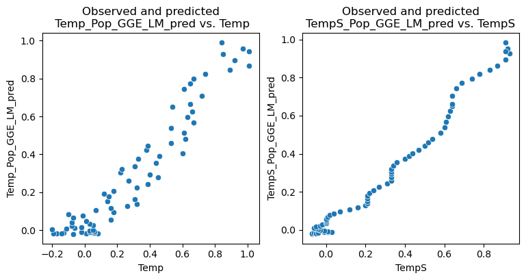

```python
plot_yhat1_and_yhat2_versus_y1_and_y2(Combined_df, 'Temp', 'TempS', 'Temp_Pop_GGE_LM_pred', 'TempS_Pop_GGE_LM_pred')
```

```python
print('Temp: The mean of the residuals = {0:4.3f}  RMSE = {1:4.3f}'.format(np.mean(Combined_df.Temp_Pop_GGE_LM_resids), np.std(Combined_df.Temp_Pop_GGE_LM_resids)))
print('TempS: The mean of the residuals = {0:4.3f}  RMSE = {1:4.3f}'.format(np.mean(Combined_df.TempS_Pop_GGE_LM_resids), np.std(Combined_df.TempS_Pop_GGE_LM_resids)))
```

```
Temp: The mean of the residuals = 0.003  RMSE = 0.097
TempS: The mean of the residuals = 0.003  RMSE = 0.046
```

**Figure 4.5.1.3** Both models seem to make quite accurate predictions with small RMSEs. Next, the residuals will be evaluated.

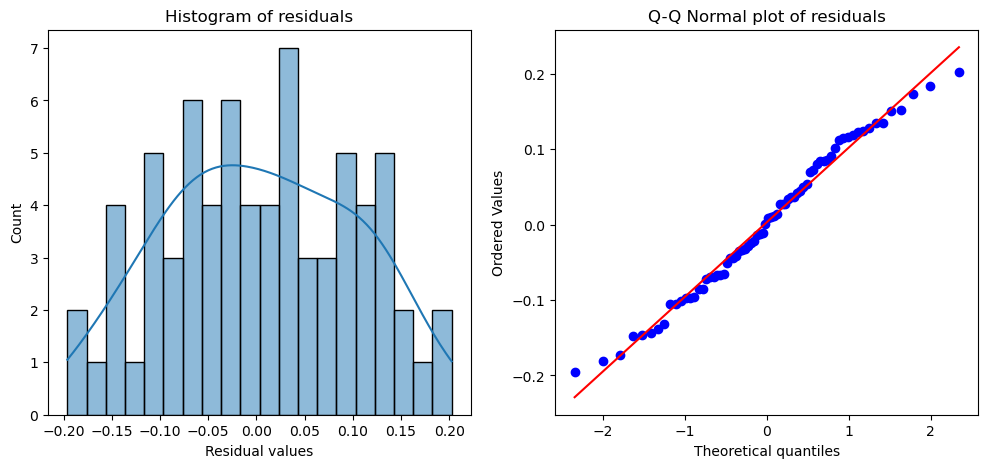

```python
plot_resid_dist(Combined_df.Temp_Pop_GGE_LM_resids)
```

**Figure 4.5.1.4** The residuals of the predicted Temp are approximately normally distributed.

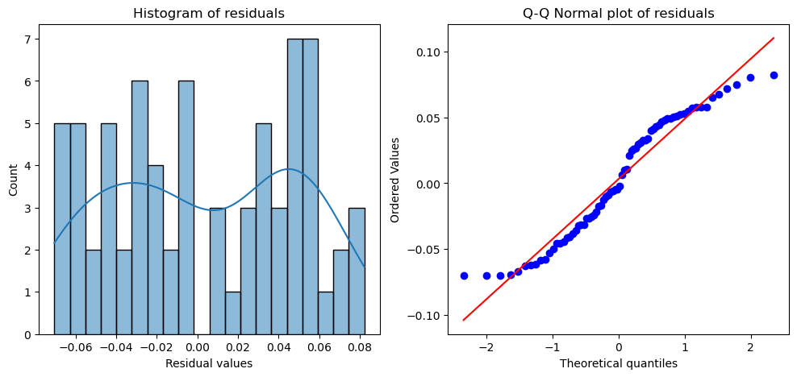

```python
plot_resid_dist(Combined_df.TempS_Pop_GGE_LM_resids)
```

**Figure 4.5.1.5** The residuals of the predicted TempS data are bimodally distributed.

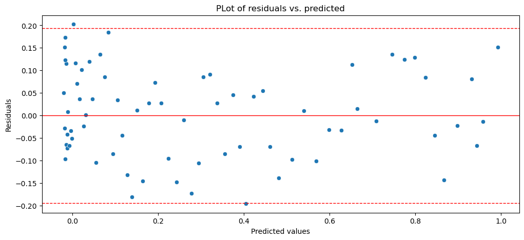

```python
residual_plot(Combined_df, 'Temp_Pop_GGE_LM_pred', 'Temp_Pop_GGE_LM_resids')
```

**Figure 4.5.1.5** The residuals of the predicted Temp data are homoskedastic.

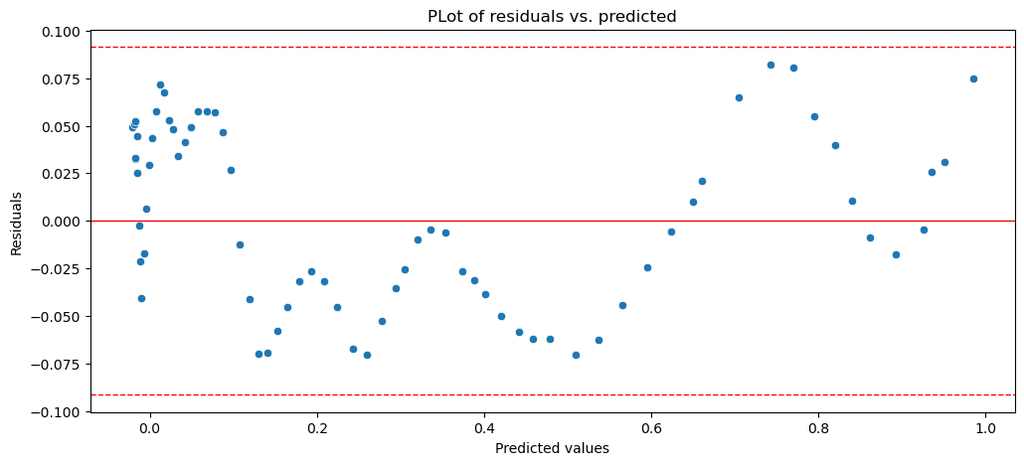

```python
residual_plot(Combined_df, 'TempS_Pop_GGE_LM_pred', 'TempS_Pop_GGE_LM_resids')
```

**Figure 4.5.1.6** The residuals of the predicted TempS data follow a pattern, again mostly due to the time series, but are overall also homoskedastic.

So far, to predict Temp and TempS, these are the best models in terms of R squared (adjusted), RMSE, and homoskedasticity.

## 4.6 World Population versus Population of Different Country Categories

### 4.6.1 Multivariate Linear Model

#### 4.6.1.1 Rationale for Multivariate Linear Model

We want to see if the population in different categories can be used to predict the global population and which country category has the strongest predictive power. This model will not be used to make predictions but rather for a qualitative purpose.

#### 4.6.1.2 Multivariate Linear Model Building

The following code builds a linear model for global population as dependent variable and population of different country categories as independent variables.

```python
# Building a linear model with world population as dependent variable and population of different country
# categories as independent variables
World_cat_pop_LM = smf.ols(formula = 'Pop ~ HiIncPop + UpMidIncPop + LoMidIncPop + LoIncPop', \
                           data=Country_categories).fit()
World_cat_pop_LM.summary()
```

OLS Regression Results

| Dep. Variable: | Pop | R-squared: | 1.000 |
| --- | --- | --- | --- |
| Model: | OLS | Adj. R-squared: | 1.000 |
| Method: | Least Squares | F-statistic: | 2.388e+08 |
| Date: | Thu, 21 Dec 2023 | Prob (F-statistic): | 7.53e-239 |
| Time: | 16:19:45 | Log-Likelihood: | -1037.0 |
| No. Observations: | 72 | AIC: | 2084. |
| Df Residuals: | 67 | BIC: | 2095. |
| Df Model: | 4 |  |  |
| Covariance Type: | nonrobust |  |  |

|  | coef | std err | t | P>\|t\| | [0.025 | 0.975] |
| --- | --- | --- | --- | --- | --- | --- |
| Intercept | -1.564e+07 | 2.48e+06 | -6.302 | 0.000 | -2.06e+07 | -1.07e+07 |
| HiIncPop | 1.0329 | 0.006 | 169.673 | 0.000 | 1.021 | 1.045 |
| UpMidIncPop | 0.9811 | 0.003 | 333.216 | 0.000 | 0.975 | 0.987 |
| LoMidIncPop | 1.0284 | 0.002 | 501.380 | 0.000 | 1.024 | 1.032 |
| LoIncPop | 0.9391 | 0.005 | 173.920 | 0.000 | 0.928 | 0.950 |

| Omnibus: | 8.969 | Durbin-Watson: | 0.161 |
| --- | --- | --- | --- |
| Prob(Omnibus): | 0.011 | Jarque-Bera (JB): | 12.248 |
| Skew: | -0.479 | Prob(JB): | 0.00219 |
| Kurtosis: | 4.780 | Cond. No. | 1.38e+11 |

Notes:  
[1] Standard Errors assume that the covariance matrix of the errors is correctly specified.  
[2] The condition number is large, 1.38e+11. This might indicate that there are  
strong multicollinearity or other numerical problems.

#### 4.6.1.3 Multivariate Linear Model Results

The population series of the different country categories are all highly correlated with the world population. The highest t value is that for low-middle-income countries, followed by upper-middle-income countries, low-income countries and high-income countries. This only tells us which trend aligns most with the global population, not what their contribution is, though.

## 4.7 World GGE versus GGE of Different Country Categories

### 4.7.1 Multivariate Linear Model

#### 4.7.1.1 Rationale for Multivariate Linear Model

We want to see if the greenhouse gas emissions in different categories can be used to predict the global GGE and which one has the highest predictive power.

#### 4.7.1.2 Multivariate Linear Model Variables Building

The following code builds a linear model for global GGE as dependent variable and GGE of different country categories as independent variables.

```python
# Building a linear model with world GGE as dependent variable and GGE of different country
# categories as independent variables
World_cat_GGE_LM = smf.ols(formula = 'GGE ~ HiIncGGE + UpMidIncGGE + LoMidIncGGE + LoIncGGE', \
                                      data=Country_categories).fit()
World_cat_GGE_LM.summary()
```

OLS Regression Results

| Dep. Variable: | GGE | R-squared: | 0.974 |
| --- | --- | --- | --- |
| Model: | OLS | Adj. R-squared: | 0.973 |
| Method: | Least Squares | F-statistic: | 636.2 |
| Date: | Thu, 21 Dec 2023 | Prob (F-statistic): | 1.71e-52 |
| Time: | 16:19:45 | Log-Likelihood: | -1488.1 |
| No. Observations: | 72 | AIC: | 2986. |
| Df Residuals: | 67 | BIC: | 2998. |
| Df Model: | 4 |  |  |
| Covariance Type: | nonrobust |  |  |

|  | coef | std err | t | P>\|t\| | [0.025 | 0.975] |
| --- | --- | --- | --- | --- | --- | --- |
| Intercept | 6.316e+08 | 1.45e+08 | 4.357 | 0.000 | 3.42e+08 | 9.21e+08 |
| HiIncGGE | 0.0282 | 0.029 | 0.974 | 0.334 | -0.030 | 0.086 |
| UpMidIncGGE | 0.1533 | 0.048 | 3.191 | 0.002 | 0.057 | 0.249 |
| LoMidIncGGE | 0.3977 | 0.108 | 3.685 | 0.000 | 0.182 | 0.613 |
| LoIncGGE | -2.1849 | 1.228 | -1.779 | 0.080 | -4.636 | 0.267 |

| Omnibus: | 4.981 | Durbin-Watson: | 0.597 |
| --- | --- | --- | --- |
| Prob(Omnibus): | 0.083 | Jarque-Bera (JB): | 4.579 |
| Skew: | -0.386 | Prob(JB): | 0.101 |
| Kurtosis: | 3.964 | Cond. No. | 9.30e+10 |

Notes:  
[1] Standard Errors assume that the covariance matrix of the errors is correctly specified.  
[2] The condition number is large, 9.3e+10. This might indicate that there are  
strong multicollinearity or other numerical problems.

#### 4.7.1.3 Multivariate Linear Model Results

This is also a very good model with an R squared adjusted of 0.97. However, we can see that the GGE development of high-income countries and low-income countries are not significant. This is because their trend goes down, while the trend of global GGE goes up. Again, this only tells us about the trend, not the absolute contribution of the different country categories.

## 4.8 World Temperature versus Population and GGE of Different Country Categories

### 4.8.1 Multivariate Linear Model

#### 4.8.1.1 Rationale for Multivariate Linear Model

We want to see which contributions to population and greenhouse gas emissions from different country categories can be used to predict the global temperature.

#### 4.8.1.2 Multivariate Linear Model Building

The following code build linear models for global temperature (Temp and TempS) as dependent variables and population and GGE of different country categories as independent variables.

```python
# Building a linear model with world Temp as dependent variable and populationa nd GGE of different country
# categories as independent variables
Temp_cat_GGE_LM = smf.ols(formula = 'Temp ~ HiIncPop + UpMidIncPop + LoMidIncPop + LoIncPop +\
                                    HiIncGGE + UpMidIncGGE + LoMidIncGGE + LoIncGGE', \
                                    data=Country_categories).fit()
Temp_cat_GGE_LM.summary()
```

OLS Regression Results

| Dep. Variable: | Temp | R-squared: | 0.624 |
| --- | --- | --- | --- |
| Model: | OLS | Adj. R-squared: | 0.576 |
| Method: | Least Squares | F-statistic: | 13.06 |
| Date: | Thu, 21 Dec 2023 | Prob (F-statistic): | 6.80e-11 |
| Time: | 16:19:45 | Log-Likelihood: | 67.602 |
| No. Observations: | 72 | AIC: | -117.2 |
| Df Residuals: | 63 | BIC: | -96.71 |
| Df Model: | 8 |  |  |
| Covariance Type: | nonrobust |  |  |

|  | coef | std err | t | P>\|t\| | [0.025 | 0.975] |
| --- | --- | --- | --- | --- | --- | --- |
| Intercept | -0.3446 | 0.943 | -0.366 | 0.716 | -2.228 | 1.539 |
| HiIncPop | 1.124e-09 | 1.84e-09 | 0.612 | 0.543 | -2.55e-09 | 4.79e-09 |
| UpMidIncPop | -1.63e-09 | 8.68e-10 | -1.879 | 0.065 | -3.36e-09 | 1.03e-10 |
| LoMidIncPop | 1.54e-09 | 7.97e-10 | 1.932 | 0.058 | -5.31e-11 | 3.13e-09 |
| LoIncPop | -2.746e-09 | 3.36e-09 | -0.816 | 0.417 | -9.47e-09 | 3.98e-09 |
| HiIncGGE | 1.579e-11 | 2.25e-11 | 0.703 | 0.484 | -2.91e-11 | 6.07e-11 |
| UpMidIncGGE | 7.496e-11 | 2.36e-11 | 3.175 | 0.002 | 2.78e-11 | 1.22e-10 |
| LoMidIncGGE | -9.457e-11 | 1.63e-10 | -0.578 | 0.565 | -4.21e-10 | 2.32e-10 |
| LoIncGGE | -1.349e-09 | 6.72e-10 | -2.006 | 0.049 | -2.69e-09 | -5.3e-12 |

| Omnibus: | 1.361 | Durbin-Watson: | 1.148 |
| --- | --- | --- | --- |
| Prob(Omnibus): | 0.506 | Jarque-Bera (JB): | 1.227 |
| Skew: | 0.162 | Prob(JB): | 0.542 |
| Kurtosis: | 2.448 | Cond. No. | 1.44e+12 |

Notes:  
[1] Standard Errors assume that the covariance matrix of the errors is correctly specified.  
[2] The condition number is large, 1.44e+12. This might indicate that there are  
strong multicollinearity or other numerical problems.

```python
# Building a linear model with world TempS as dependent variable and populationa nd GGE of different country
# categories as independent variables
TempS_cat_GGE_LM = smf.ols(formula = 'TempS ~ HiIncPop + UpMidIncPop + LoMidIncPop + LoIncPop +\
                                    HiIncGGE + UpMidIncGGE + LoMidIncGGE + LoIncGGE', \
                                    data=Country_categories).fit()
TempS_cat_GGE_LM.summary()
```

OLS Regression Results

| Dep. Variable: | TempS | R-squared: | 0.849 |
| --- | --- | --- | --- |
| Model: | OLS | Adj. R-squared: | 0.830 |
| Method: | Least Squares | F-statistic: | 44.42 |
| Date: | Thu, 21 Dec 2023 | Prob (F-statistic): | 4.91e-23 |
| Time: | 16:19:45 | Log-Likelihood: | 113.89 |
| No. Observations: | 72 | AIC: | -209.8 |
| Df Residuals: | 63 | BIC: | -189.3 |
| Df Model: | 8 |  |  |
| Covariance Type: | nonrobust |  |  |

|  | coef | std err | t | P>\|t\| | [0.025 | 0.975] |
| --- | --- | --- | --- | --- | --- | --- |
| Intercept | -0.1208 | 0.496 | -0.244 | 0.808 | -1.111 | 0.870 |
| HiIncPop | 7.04e-10 | 9.65e-10 | 0.729 | 0.469 | -1.23e-09 | 2.63e-09 |
| UpMidIncPop | -1.646e-09 | 4.56e-10 | -3.609 | 0.001 | -2.56e-09 | -7.35e-10 |
| LoMidIncPop | 1.482e-09 | 4.19e-10 | 3.537 | 0.001 | 6.45e-10 | 2.32e-09 |
| LoIncPop | -2.162e-09 | 1.77e-09 | -1.222 | 0.226 | -5.7e-09 | 1.37e-09 |
| HiIncGGE | 1.851e-11 | 1.18e-11 | 1.568 | 0.122 | -5.08e-12 | 4.21e-11 |
| UpMidIncGGE | 4.889e-11 | 1.24e-11 | 3.938 | 0.000 | 2.41e-11 | 7.37e-11 |
| LoMidIncGGE | -7.643e-11 | 8.59e-11 | -0.889 | 0.377 | -2.48e-10 | 9.53e-11 |
| LoIncGGE | -7.916e-10 | 3.54e-10 | -2.239 | 0.029 | -1.5e-09 | -8.51e-11 |

| Omnibus: | 1.388 | Durbin-Watson: | 0.199 |
| --- | --- | --- | --- |
| Prob(Omnibus): | 0.500 | Jarque-Bera (JB): | 1.339 |
| Skew: | 0.319 | Prob(JB): | 0.512 |
| Kurtosis: | 2.801 | Cond. No. | 1.44e+12 |

Notes:  
[1] Standard Errors assume that the covariance matrix of the errors is correctly specified.  
[2] The condition number is large, 1.44e+12. This might indicate that there are  
strong multicollinearity or other numerical problems.

#### 4.8.1.3 Multivariate Linear Model Results

The model for Temp (the raw temperature data) is decent but not great with an R squared adjusted of 0.58. Actually, most independent variables are not significant, except upper-middle-income country GGE and low-income country GGE.

The model for TempS (the smoothed temperature) is significantly better with an R squared adjusted of 0.83. Here, four independent variables are significant: upper-middle-income country population, lower-middle-income country population, upper-middle-income country GGE and low-income country GGE. The latter two were also significant in the model for Temp.

In summary, although stratifying the population and GGE data by country categories is interesting and gives some insights, it does not improve the linear models.

## 4.9 Temperature Time Series Model

### 4.9.1 SARIMAX Model

#### 4.9.1.1 Rationale for SARIMAX Model

The pm.auto_arima function is automated function to find the best ARIMA model.

#### 4.9.1.2 SARIMAX Model Building

The following code builds best models using the pm.auto_arima function with either the Temp or the TempS data. m was set to 1 for nonseasonal data, d and D to None, which means the program will determine them, which seemed to work best. Since we don't have any seasonality or exogenous variables in our data, we are really only using the ARIMA part of the SARIMAX program. Everything after January 1, 2010 is left out of the model building and will be forecast.

```python
ts_Temp_to2009 = ts_Temp[:'2009-12-31']
best_model_Temp = pm.auto_arima(ts_Temp_to2009,
                             max_p=3, max_q=3,
                             max_P=3, max_Q=3,
                             m=1, seasonal=False,
                             d=None, D=None, trace=True,
                             information_criterion = 'bic',
                             error_action='ignore',  # don't want to know if an order does not work
                             suppress_warnings=True,  # don't want convergence warnings
                             stepwise=True)  # set to stepwise)
```

```
Performing stepwise search to minimize bic
 ARIMA(2,1,2)(0,0,0)[0] intercept   : BIC=-194.992, Time=0.10 sec
 ARIMA(0,1,0)(0,0,0)[0] intercept   : BIC=-189.405, Time=0.01 sec
 ARIMA(1,1,0)(0,0,0)[0] intercept   : BIC=-191.723, Time=0.04 sec
 ARIMA(0,1,1)(0,0,0)[0] intercept   : BIC=-200.964, Time=0.02 sec
 ARIMA(0,1,0)(0,0,0)[0]             : BIC=-193.848, Time=0.01 sec
 ARIMA(1,1,1)(0,0,0)[0] intercept   : BIC=-202.815, Time=0.05 sec
 ARIMA(2,1,1)(0,0,0)[0] intercept   : BIC=-199.413, Time=0.08 sec
 ARIMA(1,1,2)(0,0,0)[0] intercept   : BIC=-199.012, Time=0.07 sec
 ARIMA(0,1,2)(0,0,0)[0] intercept   : BIC=-203.685, Time=0.03 sec
 ARIMA(0,1,3)(0,0,0)[0] intercept   : BIC=-199.182, Time=0.08 sec
 ARIMA(1,1,3)(0,0,0)[0] intercept   : BIC=-199.781, Time=0.09 sec
 ARIMA(0,1,2)(0,0,0)[0]             : BIC=-205.551, Time=0.02 sec
 ARIMA(0,1,1)(0,0,0)[0]             : BIC=-204.170, Time=0.07 sec
 ARIMA(1,1,2)(0,0,0)[0]             : BIC=-200.738, Time=0.02 sec
 ARIMA(0,1,3)(0,0,0)[0]             : BIC=-200.797, Time=0.03 sec
 ARIMA(1,1,1)(0,0,0)[0]             : BIC=-204.434, Time=0.02 sec
 ARIMA(1,1,3)(0,0,0)[0]             : BIC=-201.367, Time=0.06 sec

Best model:  ARIMA(0,1,2)(0,0,0)[0]
Total fit time: 0.776 seconds
```

```python
ts_TempS_to2009 = ts_TempS[:'2009-12-31']
best_model_TempS = pm.auto_arima(ts_Temp_to2009,
                             max_p=3, max_q=3,
                             max_P=3, max_Q=3,
                             m=1, seasonal=False,
                             d=None, D=None, trace=True,
                             information_criterion = 'bic',
                             error_action='ignore',  # don't want to know if an order does not work
                             suppress_warnings=True,  # don't want convergence warnings
                             stepwise=True)  # set to stepwise)
```

```
Performing stepwise search to minimize bic
 ARIMA(2,1,2)(0,0,0)[0] intercept   : BIC=-194.992, Time=0.09 sec
 ARIMA(0,1,0)(0,0,0)[0] intercept   : BIC=-189.405, Time=0.01 sec
 ARIMA(1,1,0)(0,0,0)[0] intercept   : BIC=-191.723, Time=0.04 sec
 ARIMA(0,1,1)(0,0,0)[0] intercept   : BIC=-200.964, Time=0.02 sec
 ARIMA(0,1,0)(0,0,0)[0]             : BIC=-193.848, Time=0.01 sec
 ARIMA(1,1,1)(0,0,0)[0] intercept   : BIC=-202.815, Time=0.05 sec
 ARIMA(2,1,1)(0,0,0)[0] intercept   : BIC=-199.413, Time=0.08 sec
 ARIMA(1,1,2)(0,0,0)[0] intercept   : BIC=-199.012, Time=0.07 sec
 ARIMA(0,1,2)(0,0,0)[0] intercept   : BIC=-203.685, Time=0.03 sec
 ARIMA(0,1,3)(0,0,0)[0] intercept   : BIC=-199.182, Time=0.08 sec
 ARIMA(1,1,3)(0,0,0)[0] intercept   : BIC=-199.781, Time=0.09 sec
 ARIMA(0,1,2)(0,0,0)[0]             : BIC=-205.551, Time=0.02 sec
 ARIMA(0,1,1)(0,0,0)[0]             : BIC=-204.170, Time=0.01 sec
 ARIMA(1,1,2)(0,0,0)[0]             : BIC=-200.738, Time=0.02 sec
 ARIMA(0,1,3)(0,0,0)[0]             : BIC=-200.797, Time=0.03 sec
 ARIMA(1,1,1)(0,0,0)[0]             : BIC=-204.434, Time=0.02 sec
 ARIMA(1,1,3)(0,0,0)[0]             : BIC=-201.367, Time=0.07 sec

Best model:  ARIMA(0,1,2)(0,0,0)[0]
Total fit time: 0.725 seconds
```

```python
best_model_Temp.summary()
```

SARIMAX Results

| Dep. Variable: | y | No. Observations: | 130 |
| --- | --- | --- | --- |
| Model: | SARIMAX(0, 1, 2) | Log Likelihood | 110.065 |
| Date: | Thu, 21 Dec 2023 | AIC | -214.130 |
| Time: | 16:19:47 | BIC | -205.551 |
| Sample: | 12-31-1880 | HQIC | -210.644 |
|  | - 12-31-2009 |  |  |
| Covariance Type: | opg |  |  |

|  | coef | std err | z | P>\|z\| | [0.025 | 0.975] |
| --- | --- | --- | --- | --- | --- | --- |
| ma.L1 | -0.3695 | 0.091 | -4.051 | 0.000 | -0.548 | -0.191 |
| ma.L2 | -0.2029 | 0.096 | -2.107 | 0.035 | -0.392 | -0.014 |
| sigma2 | 0.0106 | 0.002 | 6.100 | 0.000 | 0.007 | 0.014 |

| Ljung-Box (L1) (Q): | 0.03 | Jarque-Bera (JB): | 3.65 |
| --- | --- | --- | --- |
| Prob(Q): | 0.87 | Prob(JB): | 0.16 |
| Heteroskedasticity (H): | 1.24 | Skew: | -0.11 |
| Prob(H) (two-sided): | 0.49 | Kurtosis: | 2.20 |

Warnings:  
[1] Covariance matrix calculated using the outer product of gradients (complex-step).

```python
best_model_TempS.summary()
```

SARIMAX Results

| Dep. Variable: | y | No. Observations: | 130 |
| --- | --- | --- | --- |
| Model: | SARIMAX(0, 1, 2) | Log Likelihood | 110.065 |
| Date: | Thu, 21 Dec 2023 | AIC | -214.130 |
| Time: | 16:19:47 | BIC | -205.551 |
| Sample: | 12-31-1880 | HQIC | -210.644 |
|  | - 12-31-2009 |  |  |
| Covariance Type: | opg |  |  |

|  | coef | std err | z | P>\|z\| | [0.025 | 0.975] |
| --- | --- | --- | --- | --- | --- | --- |
| ma.L1 | -0.3695 | 0.091 | -4.051 | 0.000 | -0.548 | -0.191 |
| ma.L2 | -0.2029 | 0.096 | -2.107 | 0.035 | -0.392 | -0.014 |
| sigma2 | 0.0106 | 0.002 | 6.100 | 0.000 | 0.007 | 0.014 |

| Ljung-Box (L1) (Q): | 0.03 | Jarque-Bera (JB): | 3.65 |
| --- | --- | --- | --- |
| Prob(Q): | 0.87 | Prob(JB): | 0.16 |
| Heteroskedasticity (H): | 1.24 | Skew: | -0.11 |
| Prob(H) (two-sided): | 0.49 | Kurtosis: | 2.20 |

Warnings:  
[1] Covariance matrix calculated using the outer product of gradients (complex-step).